# A7: SE Estimation

Havisha Khurana

2025-02-25

## SE Estimation

### Simulating the DGP

**Part 1.** Simulate a DGP in which treatment is imposed on a fraction of units in a panel. Plot a representative iteration of this DGP, clearly demonstrating (i) where treatment falls and (ii) which observations are part of the treatment group and which are part of the control groups. (*I am again asking for the classic DiD plot, showing parallel trends and the level shift induced by treatment.*) Be sure to have noise terms entering though $e_i$, $e_t$, and $e_{it}$, and many cross-sectional units. (*You’ll also want to add a lot of variation in i and t, initially.*)

```r
# loading the libraries
library(fixest)
library(tidyverse)
library(broom)
```

**The DGP:**

```r
# setting time and individual parameters
n_t <- 20
n_i <- 40

# description of parameters
# difference between treatment and control group: beta_x
# diff between treated and untreated period: beta_tr
# effect of treatment in treated period: beta_xtr = 1
# effect of time/year - linear: beta_t = 0
# heterogeneous effect of time in treated period: beta_ttr = 0

simulate_panel <- function(seed = 1, n_t, n_i,
                           beta_x = 1, beta_tr = 0, beta_xtr = 1,
                           beta_t = 0, beta_ttr = 0, i_mean = 0, i_sd = 1, t_mean = 0, t_sd = 1, it_mean = 0, it_sd = 1){

cross <- tibble(
    i = 1:n_i,
    # assignment to treatment
    x = rep(0:1, each = n_i/2),
    # length of the panel
    t_length = n_t,
    # individual-level error term
    ei = rnorm(length(1:n_i), i_mean, i_sd)
)

year <- tibble(
    t = 1:n_t,
    # year-level error term
    et = rnorm(length(1:n_t), t_mean, t_sd)
)

panel <- plyr::ddply(cross, ~i, transform, t = 1:t_length) %>%
  left_join(year, by = "t") %>%
  mutate(
    eit = rnorm(length(1:(n_i*n_t)), it_mean, it_sd),
    tr = ifelse(t>=n_t/2, 1, 0),
    xtr = x*tr,
    # with individual and time level errors
    y = 10 + beta_x*x + beta_tr*tr + beta_xtr*xtr + beta_t*t + beta_ttr*t*tr + eit + ei + et
  )

return(panel)
}
```

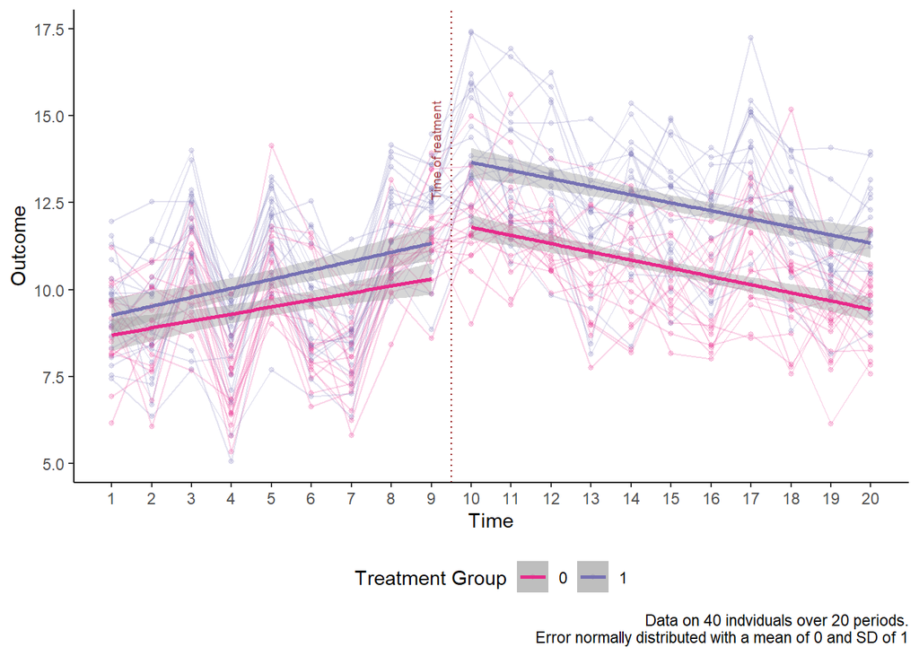

```r
error_sd <- c(1,5,10,20)

gen_did_plot <- function(seed, error_sd, n_i, n_t){

  df <- simulate_panel(seed = seed, n_t = n_t, n_i = n_i,
                              i_sd = error_sd, t_sd = error_sd, it_sd = error_sd)

  plot <- ggplot(df, aes(x = t, y = y, color = factor(x))) +
  geom_point(alpha = 0.2, size = 1) +
  geom_line(aes(group = i), alpha = 0.2) +
  geom_smooth(data = filter(df, t < 10), method = "lm") +
  geom_smooth(data = filter(df, t > 9), method = "lm") +
  labs(
    x = "Time",
    y = "Outcome",
    color = "Treatment Group",
    caption =  paste0("Data on ",max(df$i)," indviduals over ",max(df$t)," periods.\nError normally distributed with a mean of 0 and SD of ", error_sd)
  ) +
  scale_x_continuous(breaks = 1:20)+
  geom_vline(aes(xintercept = 9.5), color = "darkred", linetype = "dotted")+
  annotate(geom = "text", x = 9.1, y = 14, label = "Time of reatment",color = "darkred", angle = 90, size = 2.5, alpha = 0.7)+
  scale_color_manual(values = rev(RColorBrewer::brewer.pal(4, "Dark2"))) +
  theme_classic() +
  theme(legend.position = "bottom")

  plot
}

gen_did_plot(seed = 10,
             error_sd = error_sd[1], n_i = n_i, n_t = n_t)
```

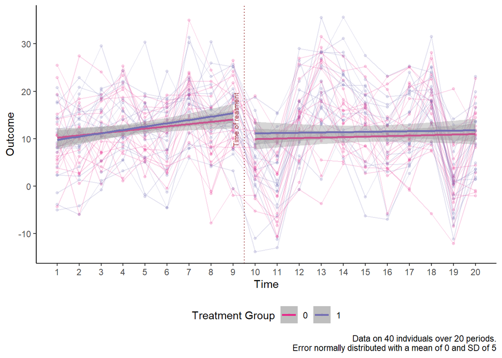

```r
gen_did_plot(seed = 10,
             error_sd = error_sd[2], n_i = n_i, n_t = n_t)
```

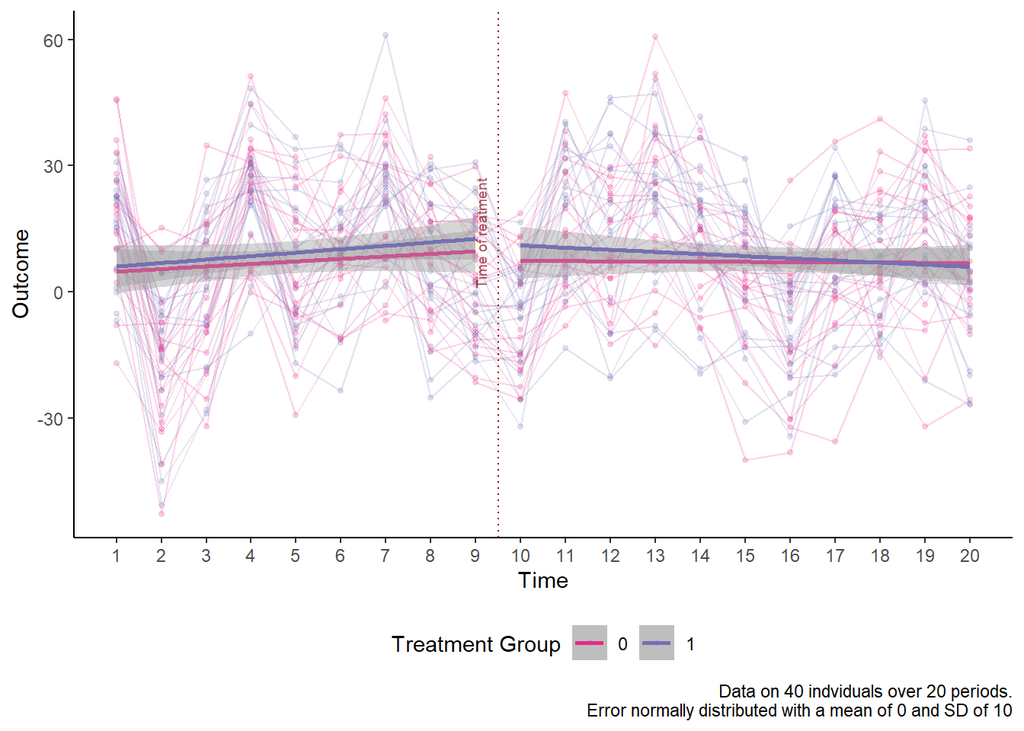

```r
gen_did_plot(seed = 10,
             error_sd = error_sd[3], n_i = n_i, n_t = n_t)
```

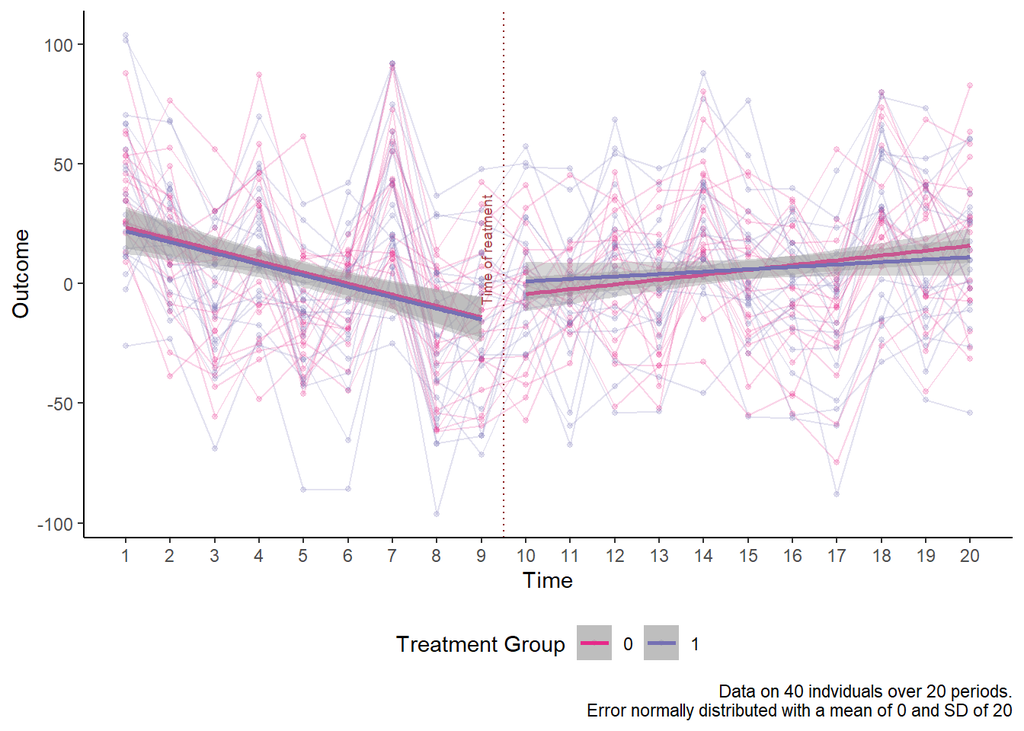

```r
gen_did_plot(seed = 10,
             error_sd = error_sd[4], n_i = n_i, n_t = n_t)
```

### DiD and TWFE Estimates

**Part 2a:** Using `feols()`, simulate (with multiple iterations) the DiD estimates of treatment, being careful to specify four different approaches to standard-error estimation— iid, allowing for clustering on *i*, *t*, and both *i* and *t* (i.e., twoway clustering). These models should be well identified, as you have not introduced any violations. Plot the distribution of SE estimates across these multiple iterations.

**Part 2b:** Using `feols()`, simulate (with multiple iterations) the TWFE estimates of treatment, being careful to specify four different approaches to standard-error estimation— iid, allowing for clustering on *i*, *t*, and both *i* and *t* (i.e., twoway clustering). These models should be well identified, as you have not introduced any violations. Plot the distribution of SE estimates across these multiple iterations.

**The simulation and Estimates**

```r
# Number of iterations
error_sd <- c(1,5,10,20)
n_iter <- 200
parameters <- expand.grid(error_sd, 1:n_iter) %>%
  rename(
    "error_sd" = "Var1",
    "seed" = "Var2"
  )

# List of dgp
dgp_list <- map2(parameters$error_sd,
                 parameters$seed,
                 ~simulate_panel(seed = .y, n_t = n_t, n_i = n_i,
                                 i_sd = .x, t_sd = .x, it_sd = .x))

# Save estimates in dgp - assuming that clusters are correctly specified

dgp_est <- function(seed, error_sd, dgp_df){

did_iid <- feols(y ~ factor(x) + tr + xtr, dgp_df, vcov="iid")

did_i <- feols(y ~ factor(x) + tr + xtr, dgp_df, cluster~i)

did_t <- feols(y ~ factor(x) + tr + xtr, dgp_df, cluster~t)

did_it <- feols(y ~ factor(x) + tr + xtr, dgp_df, cluster~i+t)

twfe_iid <- feols(y ~ xtr | i + t, dgp_df, vcov="iid")

twfe_i <- feols(y ~ xtr | i + t, dgp_df, cluster~i)

twfe_t <- feols(y ~ xtr | i + t, dgp_df, cluster~t)

twfe_it <- feols(y ~ xtr | i + t, dgp_df, cluster~i+t)


estimates <- pmap_dfr(list(list(did_iid, did_i,did_t, did_it,
                          twfe_iid, twfe_i, twfe_t, twfe_it),
                      c(rep("DiD", 4), rep("TWFE", 4)),
                      rep(c("iid", "i", "t", "it"), 2)),
  ~..1 %>%
    tidy() %>%
    filter(
      term == "xtr"
    ) %>%
    mutate(type = ..2,
           cluster = ..3,
           seed = seed,
           error_sd = error_sd)
)

  return(estimates)
}


estimate_df <- pmap_dfr(list(parameters$error_sd,
                        parameters$seed,
                        dgp_list),
                      ~dgp_est(seed = ..2,
                               error_sd = ..1,
                               dgp_df = ..3))
```

### Comparison

**Part 3.** Demonstrate the implications of changing the amount of variation entering into the DGP through *i*, *t*, and *it*.

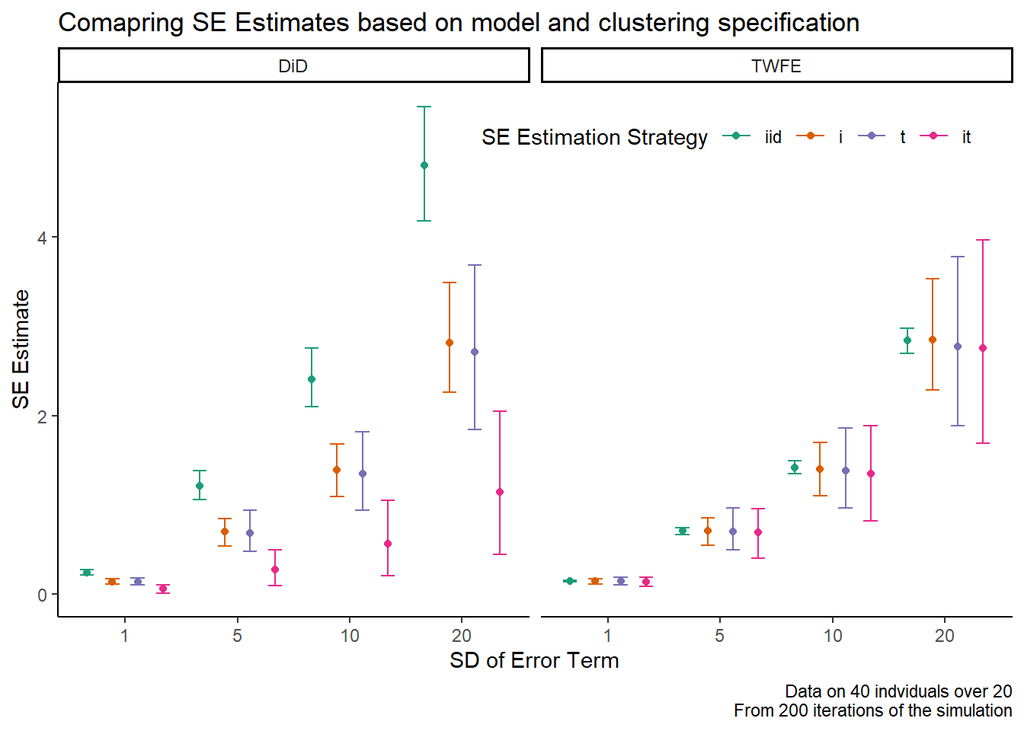

```r
estimate_df %>%
  group_by(cluster, type, error_sd) %>%
  summarize(
    mean_sd = mean(std.error),
    ci_low = quantile(std.error, 0.025),
    ci_high = quantile(std.error, 0.975)
  ) %>%
  mutate(cluster = factor(cluster,
                          levels = c("iid", "i", "t", "it"))) %>%
  ggplot(aes(x = factor(error_sd), y = mean_sd, color = cluster)) +
  geom_point(position = position_dodge(width = 0.9)) +
  geom_errorbar(aes(ymin = ci_low, ymax = ci_high),
                width = 0.5,position = position_dodge(width = 0.9)) +
  facet_wrap(~type) +
  theme_classic() +
  labs(
    x = "SD of Error Term",
    y = "SE Estimate",
    color = "SE Estimation Strategy",
    title = "Comapring SE Estimates based on model and clustering specification",
    caption =  paste0("Data on ",n_i," indviduals over ",n_t,
                      "\nFrom ",n_iter," iterations of the simulation")
  ) +
  theme(
    legend.position = c(0.7,0.9),
    legend.direction = "horizontal"
  ) +
  scale_color_manual(values = RColorBrewer::brewer.pal(4, "Dark2"))
```

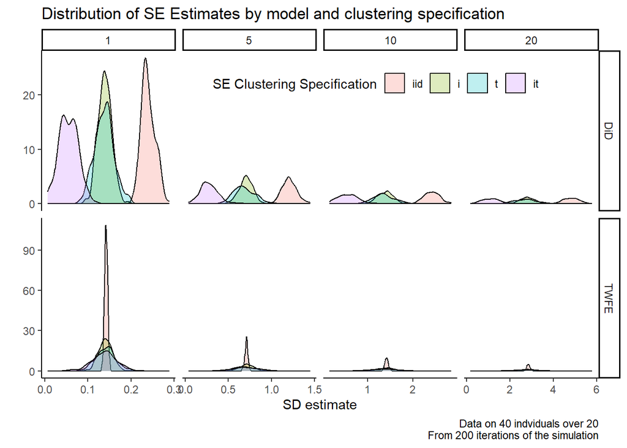

```r
estimate_df %>%
  mutate(cluster = factor(cluster,
                          levels = c("iid", "i", "t", "it"))) %>%
  ggplot(aes(x = std.error, fill = cluster)) +
  geom_density(alpha = 0.25) +
  facet_grid(type ~ error_sd,
             scales = "free") +
  theme_classic() +
  #scale_y_continuous(limits = c(0,1))+
  labs(
    x = "SD estimate",
    y = "",
    title = "Distribution of SE Estimates by model and clustering specification",
    fill = "SE Clustering Specification",
   caption =  paste0("Data on ",n_i," indviduals over ",n_t,
                      "\nFrom ",n_iter," iterations of the simulation")) +
    guides(color = "none") +
  theme(
    legend.position = c(0.6,0.9),
    legend.direction = "horizontal"
  )+
  scale_color_manual(values = RColorBrewer::brewer.pal(4, "Dark2"))
```

**In DiD**

- The average SE estimates from iid specification is always bigger and the average SE estimate when clustering at both i and t is always the smallest.
- The average SE estimate from clustering at i and clustering at t are close and switch order. Perhaps, if I change the relative error introduced at i and t, thing will look different.
- Within same error distribution, the width of the SE distribution remains about the same across clustering specification. Although the distribution around the it specification is visually larger.
- When the variation in the error terms (at i, t, and it - all together) increases, the average SE estimate becomes larger and the distribution becomes wider.

**In TWFE**

- The average SE estimates from all specifications are about the same.
- The distribution of SE estimates from iid specification is the narrowest and the distribution of SE estimates from it specification is the widest. The distribution of SE estimates with just i and just t specification are about the same, although the distribution with the i specification is slightly narrow (more i units than t units).
- When the variation in error terms increase, the average SE estimate becomes larger and the distribution becomes wider but the rank-order remains the same.